# Avaliacao 1

Arthur Hintz

14-05-2025

# Série Temporal

A série temporal foi obtida no ‘World Data Service for Paleoclimatology’, com o trabalho intitulado Boninsegna - Rio Cisne Chubut. Os dados possuem 1534 observações, começando no ano 441, com uma frequência definida a cada 72 anos.

# Análise Exploratória

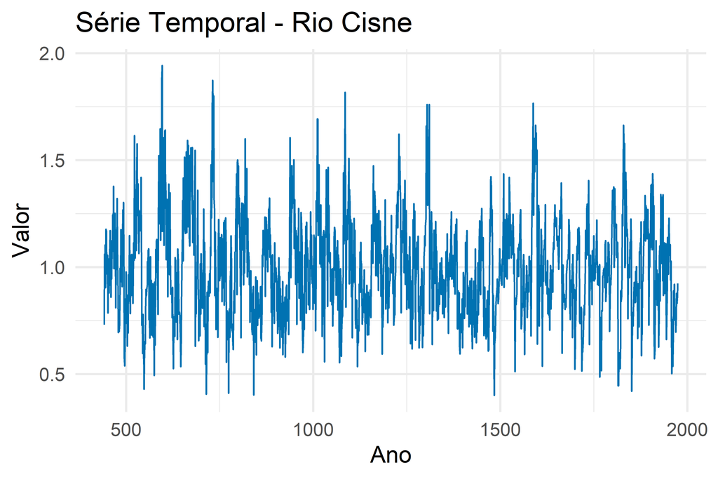

Resumo

|  | vars | n | mean | sd | median | trimmed | mad | min | max | range | skew | kurtosis | se |
| --- | --- | --- | --- | --- | --- | --- | --- | --- | --- | --- | --- | --- | --- |
| X1 | 1 | 1534 | 1 | 0.2389 | 0.986 | 0.9895 | 0.2357 | 0.4 | 1.942 | 1.542 | 0.4739 | 0.442 | 0.0061 |

Os valores observados variam de 0.4 a 1.94, sendo a média definida por 1.0000052 e o desvio padrão por 0.2389214. Inicialmente, visualiza-se um comportamento estacionário e sazonal da série.

## Função de Autocorrelação (FAC)

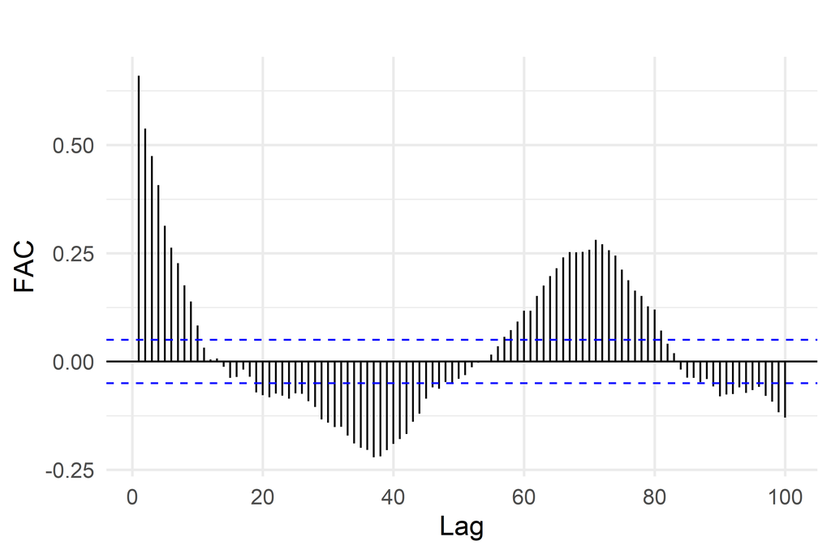

A análise da FAC sugere uma sazonalidade com período de 72 anos.

## Função de Autocorrelação Parcial (FACP)

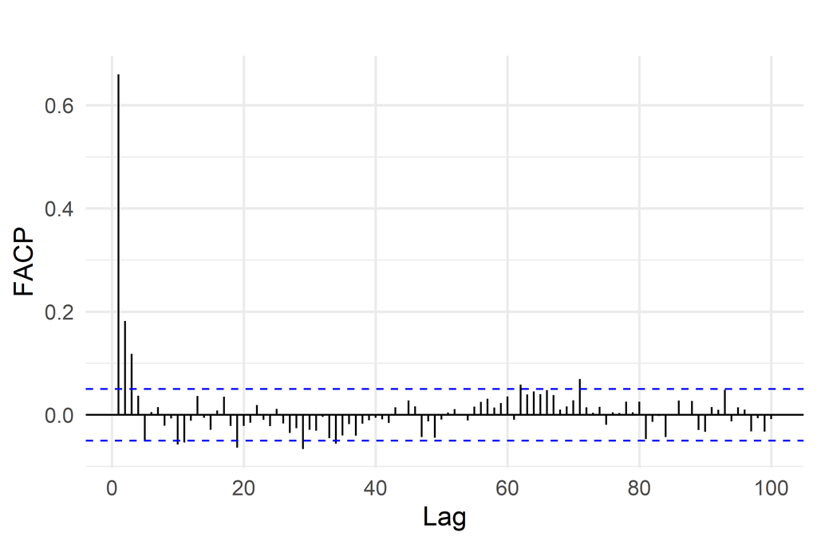

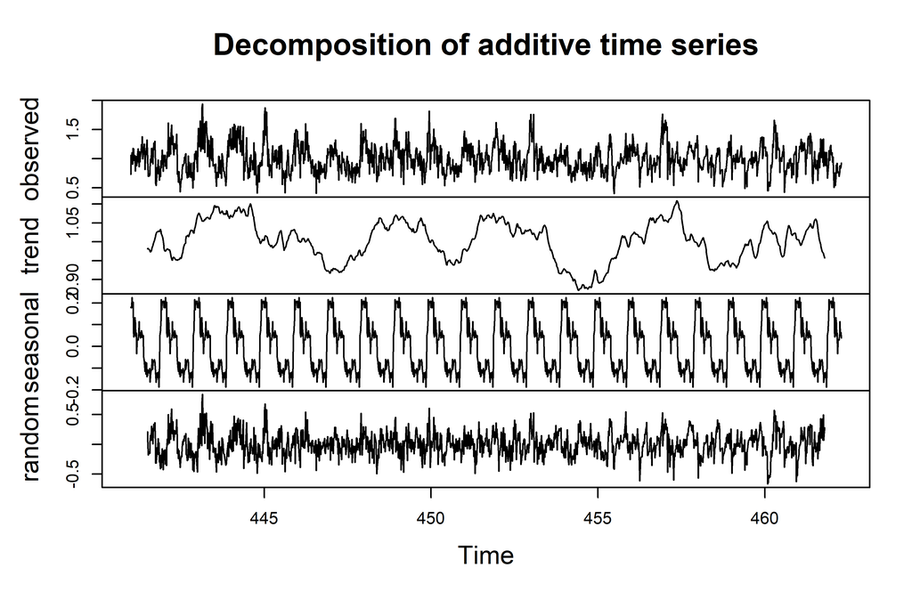

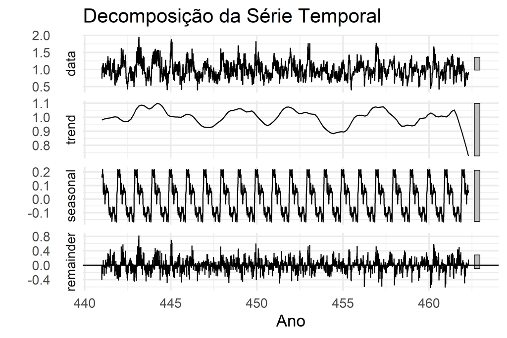

A decomposição da série temporal revela quatro componentes principais:

- Observado: a série original, com o comportamento ao longo dos anos.
- Tendência: evidencia padrões de longo prazo, como períodos de crescimento ou queda nos valores.
- Sazonalidade: comportamento padrão ao longo dos anos.
- Ruído: representa a variação não explicada, ou seja, aleatórias.

## Teste para raiz unitaria:

| Testes | H0 | p_valor | Conclusao |
| --- | --- | --- | --- |
| Augmented Dickey-Fuller | Tendencia | 0.01 | NAO tendencia |
| Phillips-Perron Unit Root | Tendencia | 0.01 | NAO tendencia |
| KPSS Test for Level | NAO tendencia | 0.10 | NAO tendencia |

Os testes indicam que a série é estacionária, sem presença de raiz unitária.

## Teste de Tendencia Deterministica:

| Testes | H0 | p_valor | Conclusao |
| --- | --- | --- | --- |
| Cox Stuart | NAO tendencia | 0.6911 | NAO tendencia |
| Cox and Stuart Trend | NAO tendencia | 0.6371 | NAO tendencia |
| Mann-Kendall Trend | NAO tendencia | 0.2007 | NAO tendencia |
| Mann-Kendall | NAO tendencia | 0.2007 | NAO tendencia |
| KPSS Test for Trend | NAO tendencia | 0.1000 | NAO tendencia |

De acordo com os testes a série não apresenta tendência deterministica

## Sazonalidade

| Testes | H0 | p_valor | Conclusao |
| --- | --- | --- | --- |
| Kruskall Wallis | NAO Sazonal | 0.8854 | NAO Sazonal |
| Friedman rank | NAO Sazonal | 0.8896 | NAO Sazonal |

Os resultados indicam que a série não apresenta sazonalidade significativa sem diferenciação.

# Ajuste do Modelo ARIMA

Inicialmente, foram ajustados dois modelos ARIMA para a série temporal. O primeiro modelo utilizou a sazonalidade da série como uma covariável. Para isso, a componente sazonal foi extraída usando a função *decompose()* e incluída como uma variável exógena. O modelo foi ajustado usando a função *auto.arima()* para selecionar as ordens mais apropriadas com base no critério AIC, resultando em um modelo final:

$$ARIMA(3,1,1) + X_t$$

onde:  
- $X_t$ é a componente sazonal extraída,  
- $ARIMA(p,d,q)$ indica o modelo autoregressivo de médias móveis com ordens $p = 3$, $d = 1$ e $q = 1$.

O segundo modelo foi ajustado sem a inclusão de covariáveis, mas com um componente sazonal capturado diretamente na especificação do modelo, resultando em um modelo

$$ARIMA(1,0,1)(0,0,1)_s$$

onde o termo $(0,0,1)_s$ captura a componente sazonal da série.

A comparação entre os dois modelos foi realizada com base em métricas de acurácia, como RMSE (Root Mean Squared Error) e MAE (Mean Absolute Error), conforme apresentados na tabela a seguir:

Métricas de Acurácia dos Modelos

|  | ME | RMSE | MAE | MPE | MAPE | MASE | ACF1 |
| --- | --- | --- | --- | --- | --- | --- | --- |
| ARIMA(3,1,1) com Covariável | -0.001 | 0.1679 | 0.1281 | -3.2653 | 13.9612 | 0.5548 | -0.0042 |
| ARIMA(1,0,1)(0,0,1) sem Covariável | 0.000 | 0.1753 | 0.1327 | -3.4531 | 14.4553 | 0.5745 | 0.0105 |

*Modelo Final*

O modelo final selecionado foi o *ARIMA(3,1,1)* com covariável sazonal. Os coeficientes ajustados são apresentados na tabela abaixo:

Parametros do Modelo ARIMA

|  | Coeficiente | Erro Padrao | Estatistica z | P-valor |
| --- | --- | --- | --- | --- |
| ar1 | 0.4780067 | 0.0253944 | 18.823303 | 0.0000000 |
| ar2 | 0.0962026 | 0.0280706 | 3.427168 | 0.0006099 |
| ar3 | 0.1164076 | 0.0254040 | 4.582245 | 0.0000046 |
| ma1 | -1.0000000 | 0.0024942 | -400.923304 | 0.0000000 |
| xreg | 0.9377267 | 0.0770271 | 12.173982 | 0.0000000 |

# Análise de Resíduos:

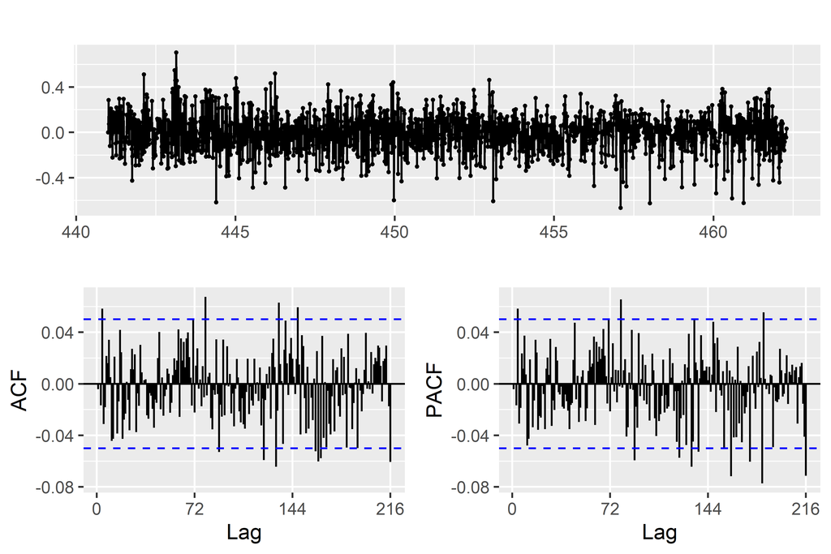

## Teste de Independência

Teste de Ljung-Box para resíduos

| statistic | p.value | parameter | method |
| --- | --- | --- | --- |
| 19.5219 | 0.191 | 15 | Box-Ljung test |

Tanto os gráficos ACF e PACF, quanto o teste de Ljung-box com 15 lags, confirmam a independência dos resíduos, indicando um bom ajuste do modelo.

## Teste de normalidade

Teste de Anderson-Darling

| statistic | p.value | method |
| --- | --- | --- |
| 3.8589 | 0 | Anderson-Darling normality test |

O teste de Anderson-Darling sugere que os resíduos não seguem uma distribuição normal, indicando possível não aderência do modelo aos pressupostos de normalidade.

## Teste da Raiz unitária

| Testes | H0 | p_valor | Conclusao |
| --- | --- | --- | --- |
| Augmented Dickey-Fuller | Tendencia | 0.01 | NAO tendencia |
| Phillips-Perron Unit Root | Tendencia | 0.01 | NAO tendencia |
| KPSS Test for Level | NAO tendencia | 0.10 | NAO tendencia |

Os residuos não apresentam raiz unitária, ou seja, são estacionários

# Previsão

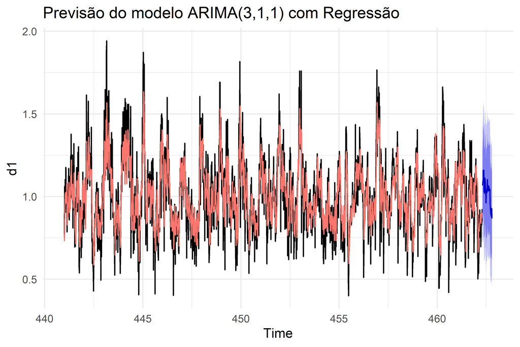

O gráfico acima mostra os valores ajustados (em laranja) e as previsões para os próximos 36 anos (em azul), evidenciando a continuidade do padrão sazonal do modelo ajustado